# Plotting Time Series with ggplot2 and ggfortify

This document explains time series related plotting using `ggplot2` and `ggfortify`.

# Installation

First, install `ggfortify` from [github](https://github.com/sinhrks/ggfortify).

```r
library(devtools)
install_github('sinhrks/ggfortify')
```

# Plotting ts objects

`ggfortify` let `ggplot2` know how to interpret `ts` objects. After loading `ggfortify`, you can use `ggplot2::autoplot` function for `ts` objects.

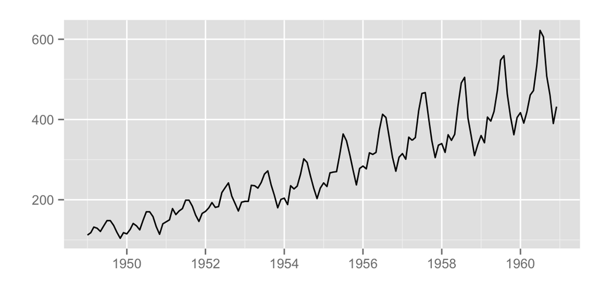

```r
library(ggplot2)
library(ggfortify)
autoplot(AirPassengers)
```

To change line colour and line type, use `ts.colour` and `ts.linetype` options. Use `help(autoplot.ts)` (or `help(autoplot.*)` for any other objects) to check available options.

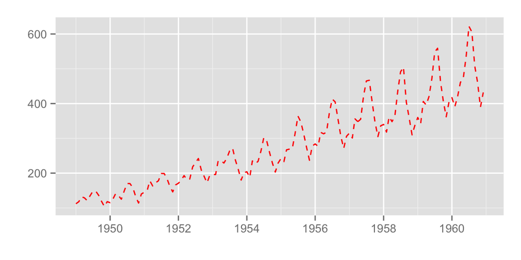

```r
autoplot(AirPassengers, ts.colour = 'red', ts.linetype = 'dashed')
```

Multivariate time series will be drawn with facets.

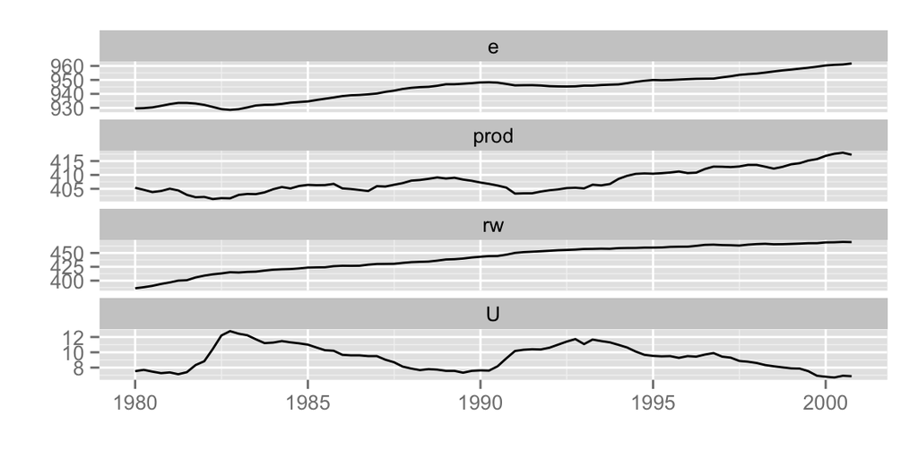

```r
library(vars)
data(Canada)
autoplot(Canada)
```

Specify `facets = FALSE` to draw on single axes.

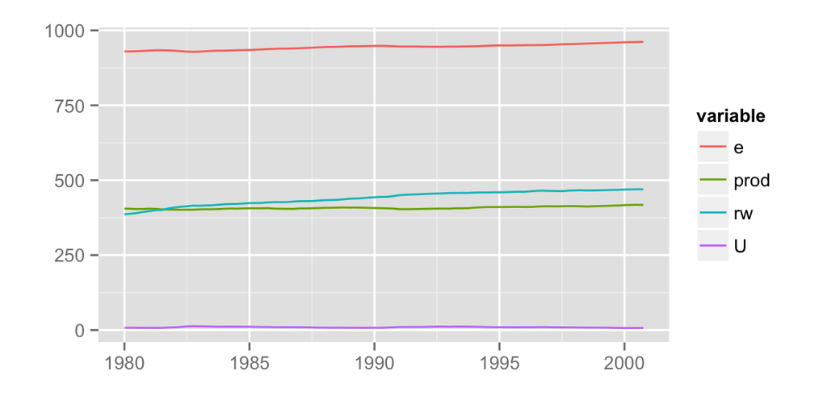

```r
autoplot(Canada, facets = FALSE)
```

Also, `autoplot` can handle other time-series-likes. Supported packages are:

- `zoo::zooreg`
- `xts::xts`
- `timeSeries::timSeries`
- `tseries::irts`

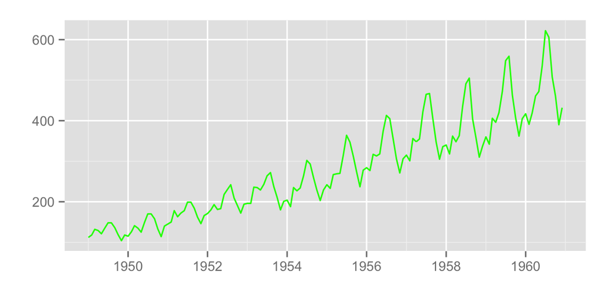

```r
library(xts)
autoplot(as.xts(AirPassengers), ts.colour = 'green')
```

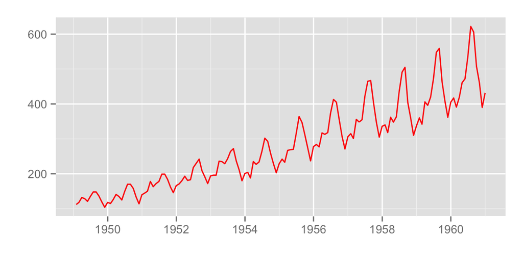

```r
library(timeSeries)
autoplot(as.timeSeries(AirPassengers), ts.colour = ('red'))
```

# Plotting with forecast package

`ggfortify` supports `forecast` object in `forecast` package.

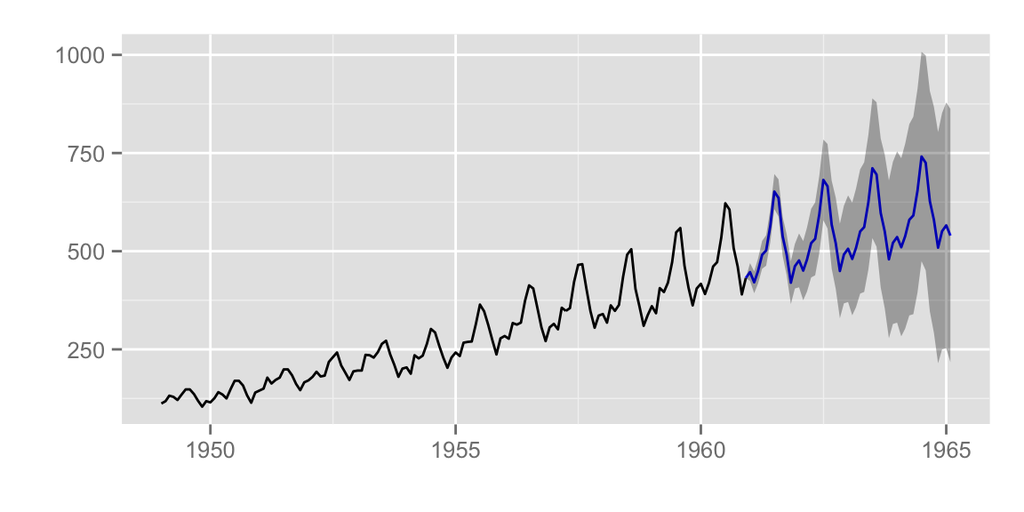

```r
library(forecast)
d.arima <- auto.arima(AirPassengers)
d.forecast <- forecast(d.arima, level = c(95), h = 50)
autoplot(d.forecast)
```

There are some options to change basic settings.

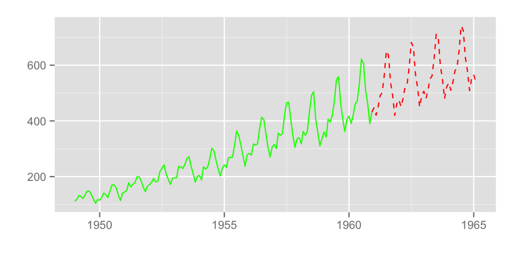

```r
autoplot(d.forecast, ts.colour = 'green', predict.colour = 'red',
         predict.linetype = 'dashed', conf.int = FALSE)
```

# Plotting with vars package

`ggfortify` supports `varpred` object in `vars` package.

```r
library(vars)
d.vselect <- VARselect(Canada, lag.max = 5, type = 'const')$selection[1]
d.var <- VAR(Canada, p = d.vselect, type = 'const')
```

Available options are the same as `forecast`.

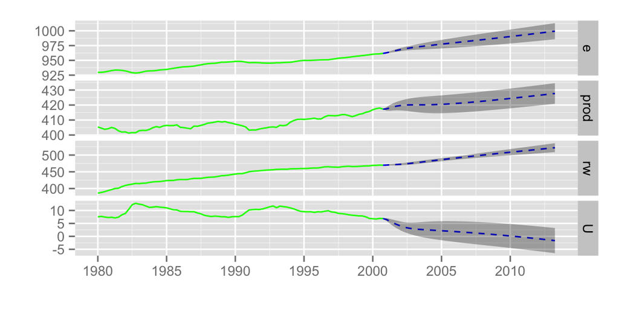

```r
autoplot(predict(d.var, n.ahead = 50), ts.colour = 'green',
         predict.colour = 'blue', predict.linetype = 'dashed')
```

# Plotting with changepoint package

`ggfortify` supports `cpt` object in `changepoint` package.

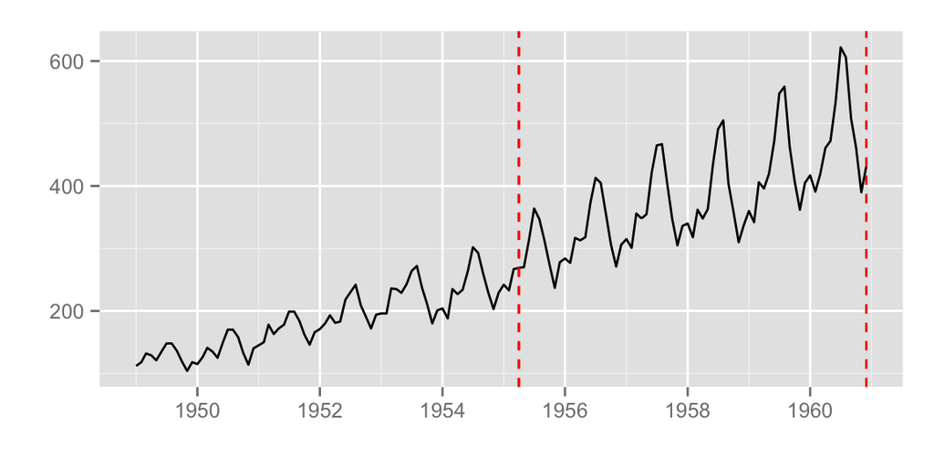

```r
library(changepoint)
autoplot(cpt.meanvar(AirPassengers))
```

You can change some options for `cpt`.

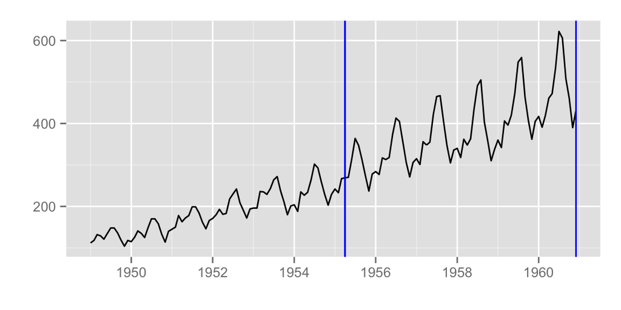

```r
autoplot(cpt.meanvar(AirPassengers), cpt.colour = 'blue', cpt.linetype = 'solid')
```

# Plotting with strucchange package

`ggfortify` supports `breakpoints` object in `strucchange` package. Same plotting options as `changepoint` are available.

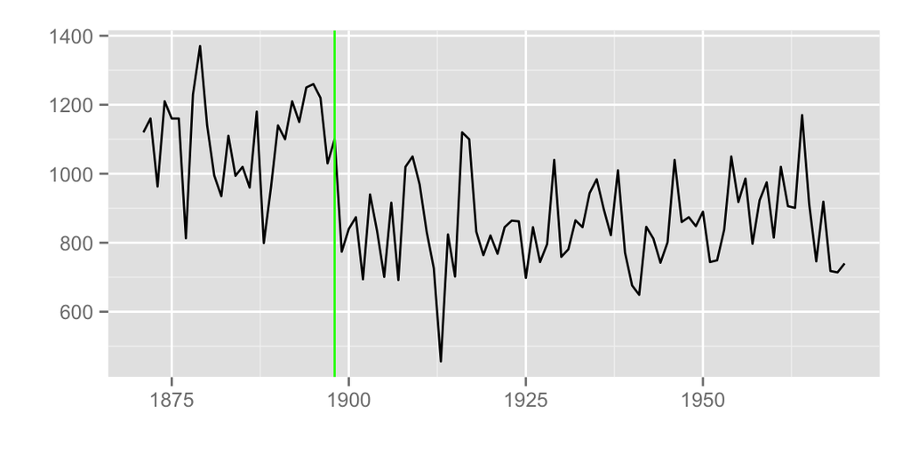

```r
library(strucchange)
autoplot(breakpoints(Nile ~ 1), cpt.colour = 'green', cpt.linetype = 'solid')
```

# Resources related to ggfortify

- [Plotting Diagnostics for LM and GLM with ggplot2 and ggfortify](http://rpubs.com/sinhrks/plot_lm)
- [Plotting Time Series with ggplot2 and ggfortify](http://rpubs.com/sinhrks/plot_ts)
- [Plotting Time Series Statistics with ggplot2 and ggfortify](http://rpubs.com/sinhrks/plot_tsstats)
- [Plotting PCA/clustering results using ggplot2 and ggfortify](http://rpubs.com/sinhrks/plot_pca)
- [Plotting Multidimensional Scaling using ggplot2 and ggfortify](http://rpubs.com/sinhrks/plot_mds)
- [Plotting Survival Curves using ggplot2 and ggfortify](http://rpubs.com/sinhrks/plot_surv)
- [Plotting Probability Distributions with ggplot2 and ggfortify](http://rpubs.com/sinhrks/plot_dist)